# shiny app example workflow - Example & web-hosted

Denis Abu Sammour

This notebook is used as blueprint for the shiny app development and dedicated vignettes.

## Accompanying data

For more info on how to properly include data into packages check [this page](https://r-pkgs.org/data.html).

**data** subdirectroy contains a pre-processed and analysis-ready RData file, containing everything needed to run an example or web-hosted shiny app. This will be included on the Github (not Git-synced).

**inst/extdata/** subdirectroy contains: (this will be part of the package but not synced by Git)  
* two txt file holding the url of the imzml (and ibd) in metaspace.  
* one tsv file containing one single continuous (full) spectrum (used for the accompanying example data).  
* one tsv file cotaning filtered swiss lipids database (used internally).  
* one csv file containing metaspace annotations for the example datase (used for the accompanying example data).

**data-external** subdirectroy contains: (this is only for development, not Git-synced and will be removed later)  
* two files; imzML and ibd, processed examplary MSI data.

**data-shinyWebHosted** subdirectroy is meant to contain processed ready-to-analyze data preferrably in .RData envirobnment type. This would ideally work with a web-hosted shiny app and will load RData on start. Please check [this page](https://shiny.rstudio.com/articles/persistent-data-storage.html) and let me know if this is actually an option. If they do not allow for data hosting we could always fetch the Github::moleculaR/data/RData file by downloading it and loading it into the session.

## Package-app inputs/outputs

**[GUI Inputs]**  
*single analyte case*  
**queryMass** numeric-insert, m/z value.  
**probMapMethod** method used to generate the molecular probability map method.  
*collective projections case*  
**lipidClass** string-dropdown, values = `searchList$allClasses`

**[GUI Outputs]**  
**plot** fwhm as a function of m/z, generated after loading the single spectrum.  
*single analyte case* **image** ion image of the `queryMass`.  
**image** ion probability map of the `queryMass`.  
*collective projections case*  
**image** collective projection of confirmed instances of the chosen `lipidClass`.  
**image** collective probability map of confirmed instances of the chosen `lipidClass`.

## Workflow for example data + web-hosted app

### Load data

```r
library(moleculaR)

#// load saved image
data("processed-example-Data")

fwhmFun           = fwhm$fwhmFun

#// create sparse matrix representation
spmat             = createSparseMat(x = msData)


# Done!
```

### plot the fwhm(m/z)

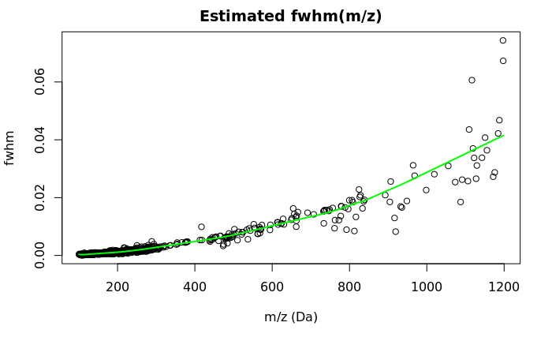

```r
p           = fwhm$fwhmValues$peaks          #peaks of the single spectrum
r           = range(p)              # range of m/z
qp          = seq(r[1], r[2])       # query peaks

plot(x = p, y = fwhm$fwhmValues$fwhmValues,
      main = "Estimated fwhm(m/z)", xlab = "m/z (Da)", ylab = "fwhm")
lines(x = qp, y = fwhmFun(qp), col = "green", lwd = 2)
```

## one analyte at a time - m/z case

```r
#// input by m/z value
queryMass         = 496.33972                                   # <-- input, numeric m/z value, use this as default value for exmaple
bwMethod          = "iterative"                                 # <-- input, c("iterative", "scott")
```

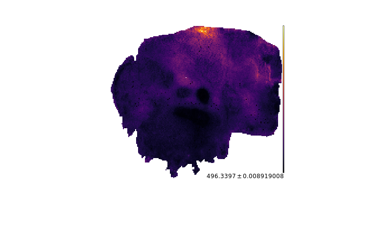

```r
#// output::ion image
s                 = MALDIquant::msiSlices(x = msData, center = queryMass,
                                          tolerance = (fwhmFun(queryMass) / 2.355) * 3)

if(sum(s, na.rm = T) == 0){
      par(mfrow = c(1, 1))
      #// image without masking
      spatstat::plot.owin(spwin,
                  main = paste0("No insances of m/z ", round(queryMass, 4), " were detected"),
                  ylim = rev(range(spwin$y)),
                  box = FALSE)
} else {

    MALDIquant::plotMsiSlice(x = s,
                             colRamp = colorRamp(viridis::viridis_pal(option = "inferno")(100)),
                             interpolate = F)

}
```

[output not shown]

```
20041 points were rejected as lying outside the specified window
```

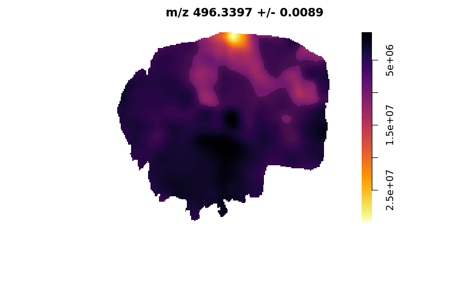

```r
#// output::molecular probability map
.uniqueMass       = as.numeric(spmat@Dimnames[[2]])


hits              = searchAnalyte(m = queryMass,
                                  fwhm = fwhmFun(queryMass),
                                  massAxis = .uniqueMass,
                                  spData = spmat,
                                  coords = MALDIquant::coordinates(msData))



#// check if hits is empty
if(nrow(hits) == 0)
{

  par(mfrow = c(1, 1))
  #// image without masking
  spatstat::plot.owin(spwin,
                  main = paste0("No insances of m/z ", round(queryMass, 4), " were detected"),
                  ylim = rev(range(spwin$y)),
                  box = FALSE)

} else {

  par(mfrow = c(1, 1))


  #// create the spatial point pattern
  hitsppp              = spatstat::ppp(x = hits$x,
                                       y = hits$y,
                                       window = spwin,
                                       marks = hits[ , -c(1, 2)])


  #// plotting

  probImg              = probMap(hitsppp, win = spwin, bwMethod = bwMethod)


  spatstat::plot.im(probImg$denspp,
                    main = paste0("m/z ", round(queryMass, 4), " +/- ", round((fwhmFun(queryMass) / 2.355) * 3, 4)),
                  col = spatstat::colourmap(viridis::viridis_pal(option = "inferno")(100), range = range(probImg$denspp, na.rm = T)),
                  ylim = rev(range(spwin$y)),
                  box = FALSE)
  spatstat::plot.im(probImg$nonHotspotMask, col = rgb(0,0,0,0.3), add = TRUE)





}
```

## Collective projection case - lipid classes

```r
#// load swiss lipid database -
# -- loaded --

#// initialize the swisslipids database
searchList           = initLipidSearch(swissdb = sldb)


#// choose one lipid species
lipidClass         = "PI(x:x)"                        # <-- Input, selection from drop-down, values = searchList$allClasses


#// load metaspace identification list
# -- loaded --

#// check if these files exist
# -- no need do in this case --

#// find peaks
.uniqueMass       = as.numeric(spmat@Dimnames[[2]])



searchList$lipidHits[[lipidClass]] = parallel::mclapply(X = seq(1, nrow(searchList$swissList[[lipidClass]])),
                                                          mc.cores = 5, FUN = function(i) {


       df            = data.frame(x = integer(0),
                            y = integer(0),
                            mass = numeric(0),
                            intensity = numeric(0),
                            adduct = character(0),
                            mode = character(0),
                            modeAdduct = character(0),
                            lipidID = character(0),
                            sumformula = character(0),
                            fullName = character(0),
                            abbrev = character(0),
                            numDoubleBonds = integer(0),
                            stringsAsFactors = F)

       msCoordinates = MALDIquant::coordinates(msData)

       #// protonated ----
       lipTmp        = searchList$swissList[[lipidClass]]$`Exact m/z of [M+H]+`[i]

              if(!is.na(lipTmp)) { # for example there is no protonated version of this lipid species

                       df     = rbind(df,
                                      searchLipid(m = lipTmp,
                                                  fwhm = fwhmFun(lipTmp),
                                                  massAxis = .uniqueMass,
                                                  spData = spmat,
                                                  coords = msCoordinates,
                                                  mtspc = mtspc, # <--
                                                  adduct = "H1",  # <--
                                                  mode = "positive",  # <--
                                                  modeAdduct = "M+H",  # <--
                                                  lipidID = searchList$swissList[[lipidClass]]$`Lipid ID`[i],
                                                  sumformula = searchList$swissList[[lipidClass]]$`Formula (pH7.3)`[i],
                                                  abbrev = searchList$swissList[[lipidClass]]$`Abbreviation*`[i],
                                                  numDoubleBonds = searchList$swissList[[lipidClass]]$numDoubleBond[i]))


              }


       #// Na+ adduct ----
       lipTmp               = searchList$swissList[[lipidClass]]$`Exact m/z of [M+Na]+`[i]

              if(!is.na(lipTmp)) { # for example there is no Na-adduct version


                       df     = rbind(df,
                                      searchLipid(m = lipTmp,
                                                  fwhm = fwhmFun(lipTmp),
                                                  massAxis = .uniqueMass,
                                                  spData = spmat,
                                                  coords = msCoordinates,
                                                  mtspc = mtspc, # <--
                                                  adduct = "Na1",  # <--
                                                  mode = "positive",  # <--
                                                  modeAdduct = "M+Na",  # <--
                                                  lipidID = searchList$swissList[[lipidClass]]$`Lipid ID`[i],
                                                  sumformula = searchList$swissList[[lipidClass]]$`Formula (pH7.3)`[i],
                                                  abbrev = searchList$swissList[[lipidClass]]$`Abbreviation*`[i],
                                                  numDoubleBonds = searchList$swissList[[lipidClass]]$numDoubleBond[i]))




              }


       #// K+ adduct ----
       lipTmp        = searchList$swissList[[lipidClass]]$`Exact m/z of [M+K]+`[i]

              if(!is.na(lipTmp)) { # for example there is no Na-adduct version

                       df     = rbind(df,
                                      searchLipid(m = lipTmp,
                                                  fwhm = fwhmFun(lipTmp),
                                                  massAxis = .uniqueMass,
                                                  spData = spmat,
                                                  coords = msCoordinates,
                                                  mtspc = mtspc, # <--
                                                  adduct = "K1",  # <--
                                                  mode = "positive",  # <--
                                                  modeAdduct = "M+K",  # <--
                                                  lipidID = searchList$swissList[[lipidClass]]$`Lipid ID`[i],
                                                  sumformula = searchList$swissList[[lipidClass]]$`Formula (pH7.3)`[i],
                                                  abbrev = searchList$swissList[[lipidClass]]$`Abbreviation*`[i],
                                                  numDoubleBonds = searchList$swissList[[lipidClass]]$numDoubleBond[i]))




              }


       return(df)
       })


#// merge
searchList$lipidHits[[lipidClass]] = do.call("rbind", searchList$lipidHits[[lipidClass]])


#// added check
if(nrow(searchList$lipidHits[[lipidClass]]) == 0) {

  par(mfrow = c(1, 1))

  #// empty window
  spatstat::plot.owin(spwin,
                  main = paste0("No insances of ", lipidClass, " were detected"),
                  ylim = rev(range(spwin$y)),
                  box = FALSE)

  detectionsExist = FALSE


} else {
  detectionsExist = TRUE
}

#// create the spatial point pattern
if(detectionsExist){

  hitsppp              = spatstat::ppp(x = searchList$lipidHits[[lipidClass]]$x,
                                     y = searchList$lipidHits[[lipidClass]]$y,
                                     window = spwin,
                                     marks = searchList$lipidHits[[lipidClass]][ , -c(1, 2)])

}


if(detectionsExist) {

  tmpm                 = unique(searchList$lipidHits[[lipidClass]]$mass) # stores unique detected masses
tmpc                 = unique(searchList$lipidHits[[lipidClass]][c("mass", "confirmed", "modeAdduct")])

cat("\nConfirmed(metaspace) | Detected(in dataset) | Total(swisslipids) = ",
   length(which(tmpc$confirmed)),
   " | ",
   length(tmpm),
   " | ",
   nrow(searchList$swissList[[lipidClass]]) * 4, # because each entry has 4 different adducts
   "\n")
cat(" M+H  detected = ", length(which(tmpc$modeAdduct == "M+H") ),
   " | ",
   "M+H  confirmed = ", length(which(tmpc$modeAdduct == "M+H" & tmpc$confirmed)),
   "\n",
   "M-H  detected = ", length(which(tmpc$modeAdduct == "M-H") ),
   " | ",
   "M-H  confirmed = ", length(which(tmpc$modeAdduct == "M-H" & tmpc$confirmed)),
   "\n",
   "M+Na detected = ", length(which(tmpc$modeAdduct == "M+Na") ),
   " | ",
   "M+Na confirmed = ", length(which(tmpc$modeAdduct == "M+Na" & tmpc$confirmed == TRUE)),"\n",
   "M+K  detected = ", length(which(tmpc$modeAdduct == "M+K") ),
   " | ",
   "M+K  confirmed = ", length(which(tmpc$modeAdduct == "M+K" & tmpc$confirmed)),
   "\n",
   "\n\n\n")
}
```

```
Confirmed(metaspace) | Detected(in dataset) | Total(swisslipids) =  3  |  7  |  1776
 M+H  detected =  4  |  M+H  confirmed =  1
 M-H  detected =  0  |  M-H  confirmed =  0
 M+Na detected =  2  |  M+Na confirmed =  1
 M+K  detected =  1  |  M+K  confirmed =  1
```

plotting all detections

[output not shown]

```
67020 points were rejected as lying outside the specified window
```

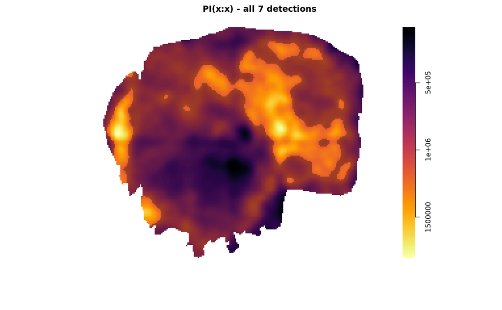

```r
if(detectionsExist) {



  probImg              = probMap(hitsppp, win = spwin, bwMethod = bwMethod)


  spatstat::plot.im(probImg$denspp,
                    main =  paste0(lipidClass, " - all ", length(tmpm), " detections"),
                  col = spatstat::colourmap(viridis::viridis_pal(option = "inferno")(100), range = range(probImg$denspp, na.rm = T)),
                  ylim = rev(range(spwin$y)),
                  box = FALSE)
  spatstat::plot.im(probImg$nonHotspotMask, col = rgb(0,0,0,0.3), add = TRUE)

}
```

plotting confirmed/verified detections

[output not shown]

```
37025 points were rejected as lying outside the specified window
```

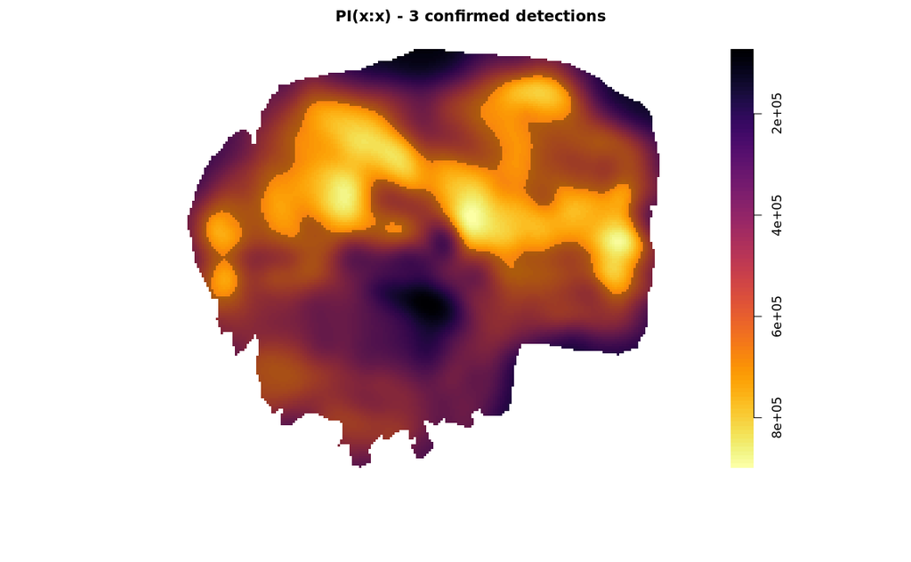

```r
if(detectionsExist) {

  subsetppp            = spatstat::subset.ppp(hitsppp, confirmed == TRUE)

#// check if empty
if(subsetppp$n == 0) {

  par(mfrow = c(1, 1))
  spatstat::plot.owin(spwin,
                    main = paste0(lipidClass, " - ", "no confirmed detections"),
                    ylim = rev(range(spwin$y)),
                    box = FALSE)


} else {



  probImg              = probMap(subsetppp, win = spwin, bwMethod = bwMethod)


  spatstat::plot.im(probImg$denspp,
                    main = paste0(lipidClass, " - ", length(which(tmpc$confirmed)), " confirmed detections"),
                  col = spatstat::colourmap(viridis::viridis_pal(option = "inferno")(100), range = range(probImg$denspp, na.rm = T)),
                  ylim = rev(range(spwin$y)),
                  box = FALSE)
  spatstat::plot.im(probImg$nonHotspotMask, col = rgb(0,0,0,0.3), add = TRUE)

}
}
```